# A Comparative Analysis: Machine Learning

# Section 8 — Model 2: Random Forest

## 8.1 Hyperparameter Tuning & Training

```r
set.seed(CONFIG$seed)

rf_tuned <- train(
  Rank_Category ~ .,
  data      = train_data,
  method    = "rf",
  trControl = cv_control,
  tuneGrid  = expand.grid(mtry = CONFIG$rf_mtry_grid),
  ntree     = CONFIG$rf_ntree,
  importance = TRUE
)

print(rf_tuned)
```

```
## Random Forest
##
## 1760 samples
##    7 predictor
##    4 classes: 'Others', 'Top100', 'Top200', 'Top500'
##
## No pre-processing
## Resampling: Cross-Validated (5 fold, repeated 3 times)
## Summary of sample sizes: 1408, 1408, 1408, 1408, 1408, 1408, ...
## Resampling results across tuning parameters:
##
##   mtry  Accuracy   Kappa
##   2     0.9206439  0.8827465
##   3     0.9217803  0.8845098
##   4     0.9221591  0.8850849
##   5     0.9227273  0.8859649
##   6     0.9217803  0.8846216
##   7     0.9221591  0.8850415
##
## Accuracy was used to select the optimal model using the largest value.
## The final value used for the model was mtry = 5.
```

```r
cat("Best mtry:", rf_tuned$bestTune$mtry, "\n")
```

```
## Best mtry: 5
```

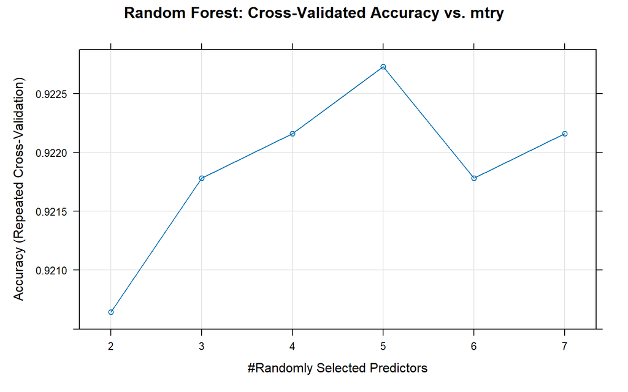

```r
plot(rf_tuned, main = "Random Forest: Cross-Validated Accuracy vs. mtry")
```

## 8.2 Prediction & Evaluation

```r
rf_model      <- rf_tuned$finalModel
rf_prediction <- predict(rf_tuned, newdata = test_data)
rf_cm         <- confusionMatrix(rf_prediction, test_data$Rank_Category)
print(rf_cm)
```

```
## Confusion Matrix and Statistics
##
##           Reference
## Prediction Others Top100 Top200 Top500
##     Others    192      0      0     12
##     Top100      0     77      2      0
##     Top200      0      3     32      6
##     Top500      8      0      6    102
##
## Overall Statistics
##
##                Accuracy : 0.9159
##                  95% CI : (0.886, 0.9401)
##     No Information Rate : 0.4545
##     P-Value [Acc > NIR] : < 2.2e-16
##
##                   Kappa : 0.8756
##
##  Mcnemar's Test P-Value : NA
##
## Statistics by Class:
##
##                      Class: Others Class: Top100 Class: Top200 Class: Top500
## Sensitivity                 0.9600        0.9625       0.80000        0.8500
## Specificity                 0.9500        0.9944       0.97750        0.9563
## Pos Pred Value              0.9412        0.9747       0.78049        0.8793
## Neg Pred Value              0.9661        0.9917       0.97995        0.9444
## Prevalence                  0.4545        0.1818       0.09091        0.2727
## Detection Rate              0.4364        0.1750       0.07273        0.2318
## Detection Prevalence        0.4636        0.1795       0.09318        0.2636
## Balanced Accuracy           0.9550        0.9785       0.88875        0.9031
```

## 8.3 Feature Importance

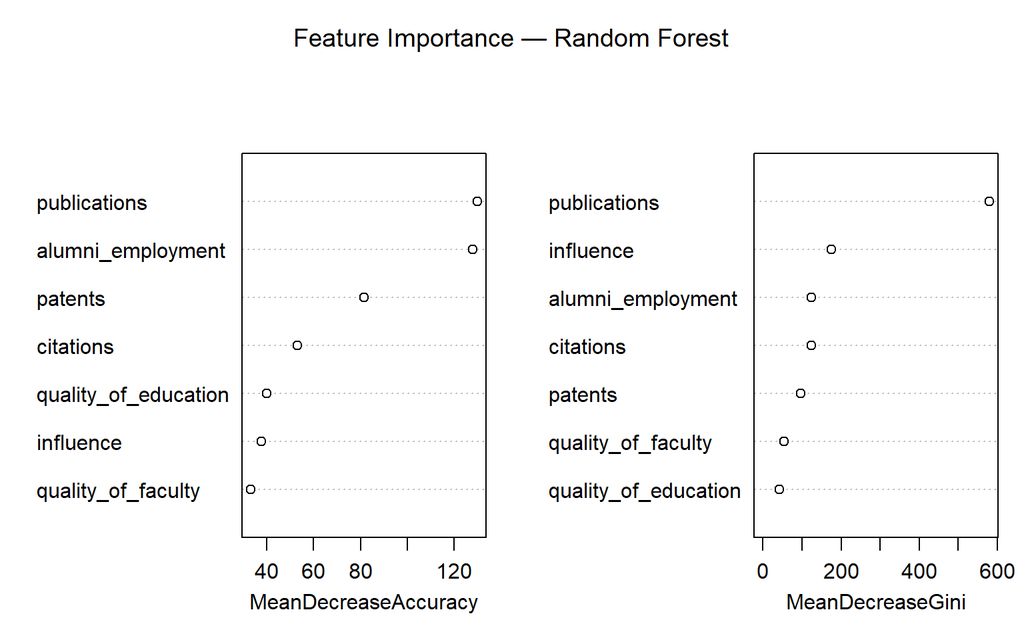

```r
varImpPlot(rf_model, main = "Feature Importance — Random Forest")
```

```r
rf_importance_df <- data.frame(
  Feature          = rownames(importance(rf_model)),
  MeanDecreaseGini = importance(rf_model)[, "MeanDecreaseGini"]
)
rf_importance_df <- rf_importance_df[order(-rf_importance_df$MeanDecreaseGini), ]

kable(rf_importance_df,
      caption  = "Random Forest — Feature Importance (Mean Decrease Gini)",
      row.names = FALSE) %>%
  kable_styling(bootstrap_options = c("striped", "hover"), full_width = FALSE)
```

Random Forest — Feature Importance (Mean Decrease Gini)

| Feature | MeanDecreaseGini |
| --- | --- |
| publications | 578.57446 |
| influence | 175.55455 |
| alumni_employment | 123.41973 |
| citations | 123.06511 |
| patents | 96.20278 |
| quality_of_faculty | 53.11510 |
| quality_of_education | 42.41255 |

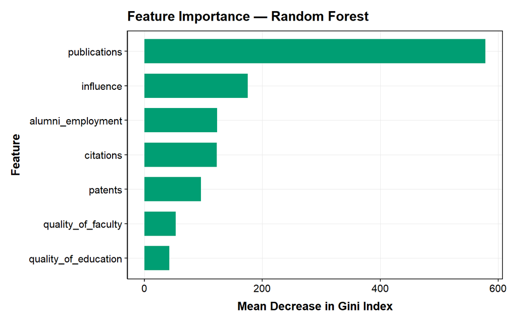

```r
ggplot(rf_importance_df,
       aes(x = reorder(Feature, MeanDecreaseGini), y = MeanDecreaseGini)) +
  geom_col(fill = PUB_PALETTE[3], width = 0.7) +
  coord_flip() +
  labs(title = "Feature Importance — Random Forest",
       x = "Feature", y = "Mean Decrease in Gini Index") +
  theme_pub()
```

## 8.4 Confusion Matrix Heatmap

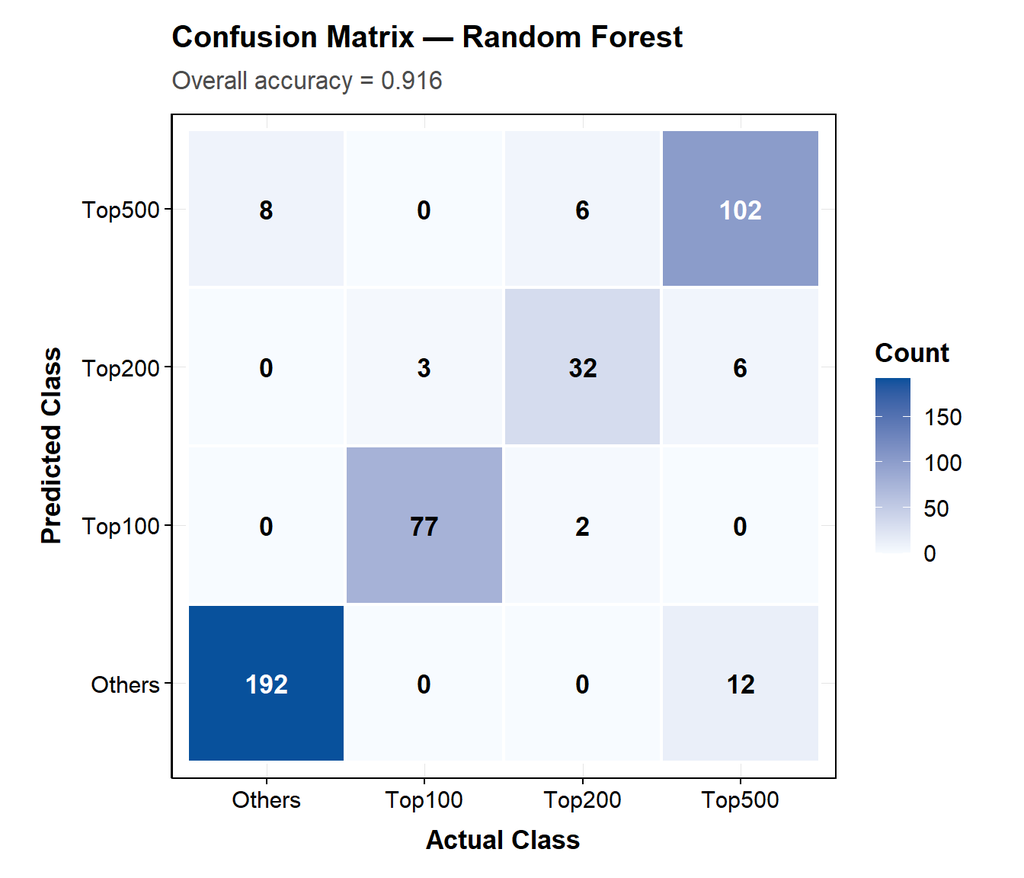

```r
p_rf_cm <- plot_confusion_matrix_heatmap(
  rf_cm,
  "Confusion Matrix — Random Forest",
  subtitle = paste0("Overall accuracy = ", round(rf_cm$overall["Accuracy"], 3))
)
print(p_rf_cm)
```

**Observation:** Random Forest reduces variance over a single Decision Tree by averaging across 500 trees. It is expected to achieve higher test accuracy, particularly on the harder Top200/Top500 boundary, due to its ensemble nature.

# Section 9 — Model 3: Multinomial Logistic Regression

## 9.1 Hyperparameter Tuning & Training

```r
set.seed(CONFIG$seed)

log_tuned <- train(
  Rank_Category ~ .,
  data      = train_data,
  method    = "multinom",
  trControl = cv_control,
  tuneGrid  = expand.grid(decay = CONFIG$logreg_decay_grid),
  trace     = FALSE,
  MaxNWts   = 10000
)

print(log_tuned)
```

```
## Penalized Multinomial Regression
##
## 1760 samples
##    7 predictor
##    4 classes: 'Others', 'Top100', 'Top200', 'Top500'
##
## No pre-processing
## Resampling: Cross-Validated (5 fold, repeated 3 times)
## Summary of sample sizes: 1408, 1408, 1408, 1408, 1408, 1408, ...
## Resampling results across tuning parameters:
##
##   decay  Accuracy   Kappa
##   0.000  0.8554924  0.7857927
##   0.001  0.8553030  0.7854689
##   0.010  0.8571970  0.7881380
##   0.050  0.8579545  0.7885281
##   0.100  0.8547348  0.7833903
##   0.500  0.8375000  0.7564267
##
## Accuracy was used to select the optimal model using the largest value.
## The final value used for the model was decay = 0.05.
```

```r
cat("Best decay:", log_tuned$bestTune$decay, "\n")
```

```
## Best decay: 0.05
```

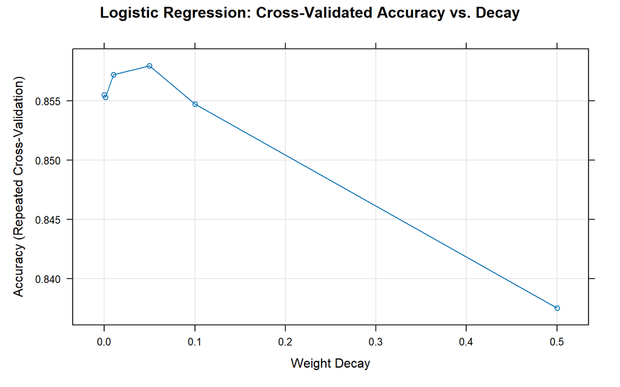

```r
plot(log_tuned, main = "Logistic Regression: Cross-Validated Accuracy vs. Decay")
```

## 9.2 Prediction & Evaluation

```r
log_model      <- log_tuned$finalModel
summary(log_model)
```

```
## Call:
## nnet::multinom(formula = .outcome ~ ., data = dat, decay = param$decay,
##     trace = FALSE, MaxNWts = 10000)
##
## Coefficients:
##        (Intercept) quality_of_education alumni_employment quality_of_faculty
## Top100    22.74236         -0.005534369      -0.018857799       -0.018426595
## Top200    16.22309         -0.002510279      -0.010790119       -0.003670943
## Top500    10.54217         -0.001184930      -0.007142466        0.002756502
##        publications    influence    citations      patents
## Top100 -0.019444607 -0.024470617  0.001159192 -0.005405654
## Top200 -0.013502716 -0.007330705 -0.006582269 -0.003250968
## Top500 -0.007319667 -0.003164189 -0.003087550 -0.001840159
##
## Std. Errors:
##        (Intercept) quality_of_education alumni_employment quality_of_faculty
## Top100   0.3791654          0.002460334      0.0015362047        0.004724131
## Top200   0.2865806          0.001984184      0.0010114856        0.004035190
## Top500   0.4672292          0.001507626      0.0007249633        0.003597302
##        publications    influence    citations      patents
## Top100 0.0032558615 0.0044960736 0.0029836333 0.0010859974
## Top200 0.0016781046 0.0016542335 0.0015441478 0.0007210584
## Top500 0.0007420211 0.0006407875 0.0006343727 0.0004528686
##
## Residual Deviance: 1265.657
## AIC: 1313.657
```

```r
levels(train_data$Rank_Category)
```

```
## [1] "Others" "Top100" "Top200" "Top500"
```

```r
log_prediction <- predict(log_tuned, newdata = test_data)
log_cm         <- confusionMatrix(log_prediction, test_data$Rank_Category)
print(log_cm)
```

```
## Confusion Matrix and Statistics
##
##           Reference
## Prediction Others Top100 Top200 Top500
##     Others    185      0      0     19
##     Top100      0     71      4      1
##     Top200      0      6     25      8
##     Top500     15      3     11     92
##
## Overall Statistics
##
##                Accuracy : 0.8477
##                  95% CI : (0.8107, 0.88)
##     No Information Rate : 0.4545
##     P-Value [Acc > NIR] : < 2.2e-16
##
##                   Kappa : 0.7743
##
##  Mcnemar's Test P-Value : NA
##
## Statistics by Class:
##
##                      Class: Others Class: Top100 Class: Top200 Class: Top500
## Sensitivity                 0.9250        0.8875       0.62500        0.7667
## Specificity                 0.9208        0.9861       0.96500        0.9094
## Pos Pred Value              0.9069        0.9342       0.64103        0.7603
## Neg Pred Value              0.9364        0.9753       0.96259        0.9122
## Prevalence                  0.4545        0.1818       0.09091        0.2727
## Detection Rate              0.4205        0.1614       0.05682        0.2091
## Detection Prevalence        0.4636        0.1727       0.08864        0.2750
## Balanced Accuracy           0.9229        0.9368       0.79500        0.8380
```

## 9.3 Confusion Matrix Heatmap

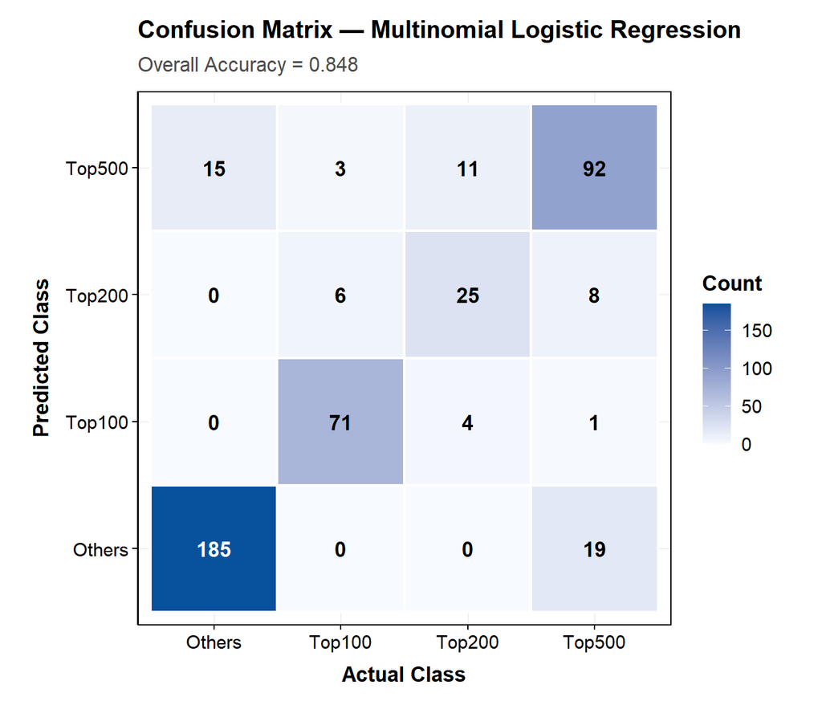

```r
# log_cm is created in log-eval above — both chunks must run in sequence
p_log_cm <- plot_confusion_matrix_heatmap(
  log_cm,
  "Confusion Matrix — Multinomial Logistic Regression",
  subtitle = paste0("Overall Accuracy = ", round(log_cm$overall["Accuracy"], 3))
)
print(p_log_cm)
```

**Observation:** Multinomial Logistic Regression provides interpretable coefficients showing the direction and magnitude of each predictor’s effect. However, its linear decision boundary may limit accuracy compared to tree-based models, particularly for the overlapping Top200/Top500 classes.

# Section 10 — Model 4: K-Nearest Neighbors

## 10.1 Hyperparameter Tuning & Training

```r
set.seed(CONFIG$seed)

knn_tuned <- train(
  x         = train_scaled[, CONFIG$predictor_cols],
  y         = train_data$Rank_Category,
  method    = "knn",
  trControl = cv_control,
  tuneGrid  = expand.grid(k = CONFIG$knn_k_grid)
)

print(knn_tuned)
```

```
## k-Nearest Neighbors
##
## 1760 samples
##    7 predictor
##    4 classes: 'Others', 'Top100', 'Top200', 'Top500'
##
## No pre-processing
## Resampling: Cross-Validated (5 fold, repeated 3 times)
## Summary of sample sizes: 1408, 1408, 1408, 1408, 1408, 1408, ...
## Resampling results across tuning parameters:
##
##   k   Accuracy   Kappa
##    3  0.8784091  0.8196319
##    5  0.8840909  0.8276394
##    7  0.8810606  0.8230518
##    9  0.8801136  0.8215685
##   11  0.8784091  0.8190049
##   13  0.8784091  0.8190948
##   15  0.8719697  0.8093615
##   17  0.8681818  0.8035965
##   19  0.8662879  0.8005006
##   21  0.8660985  0.8002434
##
## Accuracy was used to select the optimal model using the largest value.
## The final value used for the model was k = 5.
```

```r
cat("Best k:", knn_tuned$bestTune$k, "\n")
```

```
## Best k: 5
```

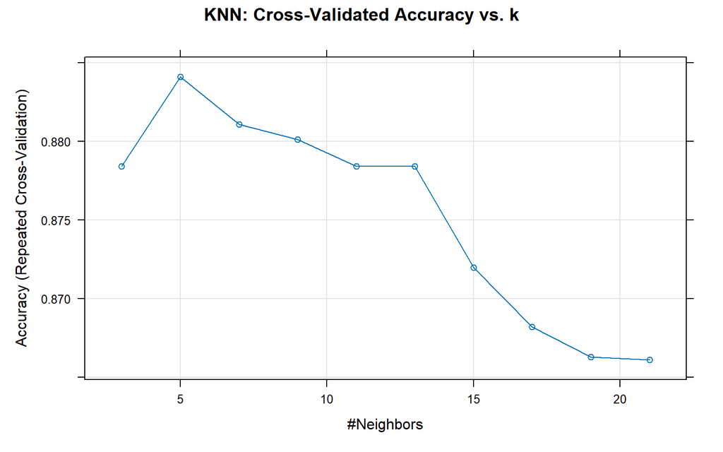

```r
plot(knn_tuned, main = "KNN: Cross-Validated Accuracy vs. k")
```

## 10.2 Prediction & Evaluation

```r
knn_prediction <- predict(knn_tuned, newdata = test_scaled[, CONFIG$predictor_cols])
knn_cm         <- confusionMatrix(
  data      = knn_prediction,
  reference = test_data$Rank_Category
)
print(knn_cm)
```

```
## Confusion Matrix and Statistics
##
##           Reference
## Prediction Others Top100 Top200 Top500
##     Others    194      0      0     14
##     Top100      0     67      1      0
##     Top200      0     10     28      7
##     Top500      6      3     11     99
##
## Overall Statistics
##
##                Accuracy : 0.8818
##                  95% CI : (0.8479, 0.9105)
##     No Information Rate : 0.4545
##     P-Value [Acc > NIR] : < 2.2e-16
##
##                   Kappa : 0.8246
##
##  Mcnemar's Test P-Value : NA
##
## Statistics by Class:
##
##                      Class: Others Class: Top100 Class: Top200 Class: Top500
## Sensitivity                 0.9700        0.8375       0.70000        0.8250
## Specificity                 0.9417        0.9972       0.95750        0.9375
## Pos Pred Value              0.9327        0.9853       0.62222        0.8319
## Neg Pred Value              0.9741        0.9651       0.96962        0.9346
## Prevalence                  0.4545        0.1818       0.09091        0.2727
## Detection Rate              0.4409        0.1523       0.06364        0.2250
## Detection Prevalence        0.4727        0.1545       0.10227        0.2705
## Balanced Accuracy           0.9558        0.9174       0.82875        0.8812
```

## 10.3 Confusion Matrix Heatmap

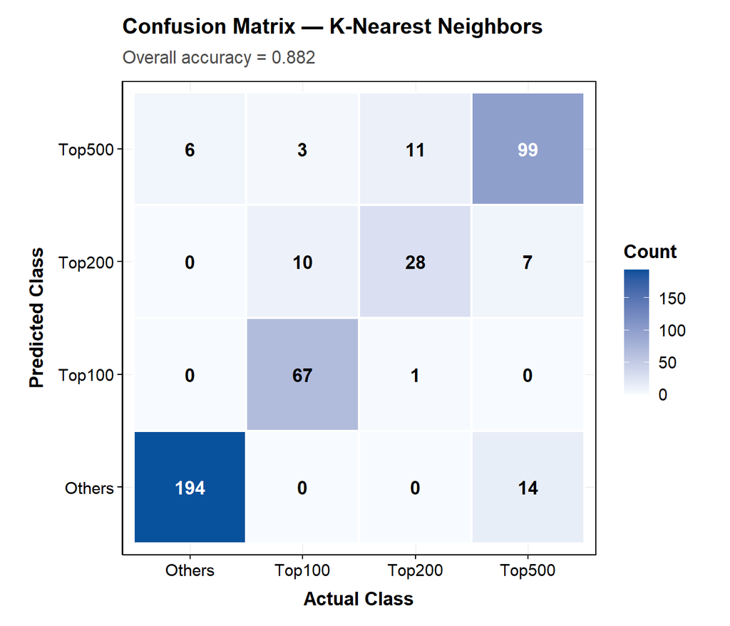

```r
p_knn_cm <- plot_confusion_matrix_heatmap(
  knn_cm,
  "Confusion Matrix — K-Nearest Neighbors",
  subtitle = paste0("Overall accuracy = ", round(knn_cm$overall["Accuracy"], 3))
)
print(p_knn_cm)
```

**Observation:** KNN requires z-score scaling (applied in Section 6.5) since it is distance-based. The optimal k is tuned via cross-validation — smaller k values capture local structure but risk overfitting, while larger k values smooth boundaries but may underfit sharp rank boundaries such as Top100.

# Section 11 — Model 5: Support Vector Machine

## 11.1 Hyperparameter Tuning & Training

```r
set.seed(CONFIG$seed)

svm_tuned <- train(
  Rank_Category ~ .,
  data      = train_scaled,
  method    = "svmRadial",
  trControl = cv_control,
  tuneGrid  = expand.grid(
    C     = CONFIG$svm_C_grid,
    sigma = CONFIG$svm_sigma_grid
  )
)

print(svm_tuned)
```

```
## Support Vector Machines with Radial Basis Function Kernel
##
## 1760 samples
##    7 predictor
##    4 classes: 'Others', 'Top100', 'Top200', 'Top500'
##
## No pre-processing
## Resampling: Cross-Validated (5 fold, repeated 3 times)
## Summary of sample sizes: 1408, 1408, 1408, 1408, 1408, 1408, ...
## Resampling results across tuning parameters:
##
##   C      sigma  Accuracy   Kappa
##     0.1  0.01   0.8231061  0.7301746
##     0.1  0.05   0.8452652  0.7668117
##     0.1  0.10   0.8564394  0.7853231
##     0.1  0.50   0.8454545  0.7675759
##     1.0  0.01   0.8541667  0.7823911
##     1.0  0.05   0.8903409  0.8372774
##     1.0  0.10   0.9020833  0.8548558
##     1.0  0.50   0.9053030  0.8598656
##    10.0  0.01   0.8888258  0.8350394
##    10.0  0.05   0.9147727  0.8739259
##    10.0  0.10   0.9179924  0.8788320
##    10.0  0.50   0.9075758  0.8632608
##   100.0  0.01   0.9147727  0.8737850
##   100.0  0.05   0.9178030  0.8784966
##   100.0  0.10   0.9183712  0.8792473
##   100.0  0.50   0.8965909  0.8469873
##
## Accuracy was used to select the optimal model using the largest value.
## The final values used for the model were sigma = 0.1 and C = 100.
```

```r
cat("Best C:", svm_tuned$bestTune$C,
    " Best sigma:", svm_tuned$bestTune$sigma, "\n")
```

```
## Best C: 100  Best sigma: 0.1
```

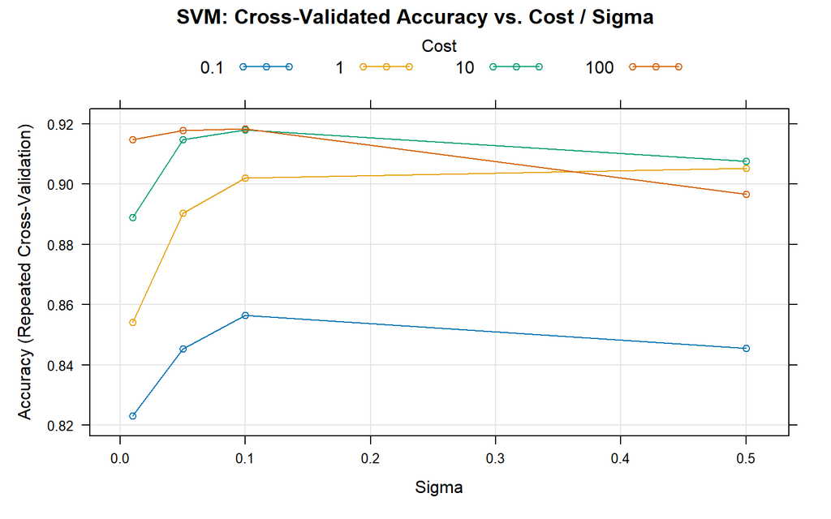

```r
plot(svm_tuned, main = "SVM: Cross-Validated Accuracy vs. Cost / Sigma")
```

## 11.2 Prediction & Evaluation

```r
svm_model      <- svm_tuned$finalModel
svm_prediction <- predict(svm_tuned, newdata = test_scaled)
svm_cm         <- confusionMatrix(svm_prediction, test_scaled$Rank_Category)
print(svm_cm)
```

```
## Confusion Matrix and Statistics
##
##           Reference
## Prediction Others Top100 Top200 Top500
##     Others    188      0      0      9
##     Top100      0     73      3      0
##     Top200      0      6     32      8
##     Top500     12      1      5    103
##
## Overall Statistics
##
##                Accuracy : 0.9
##                  95% CI : (0.8681, 0.9264)
##     No Information Rate : 0.4545
##     P-Value [Acc > NIR] : < 2.2e-16
##
##                   Kappa : 0.8531
##
##  Mcnemar's Test P-Value : NA
##
## Statistics by Class:
##
##                      Class: Others Class: Top100 Class: Top200 Class: Top500
## Sensitivity                 0.9400        0.9125       0.80000        0.8583
## Specificity                 0.9625        0.9917       0.96500        0.9437
## Pos Pred Value              0.9543        0.9605       0.69565        0.8512
## Neg Pred Value              0.9506        0.9808       0.97970        0.9467
## Prevalence                  0.4545        0.1818       0.09091        0.2727
## Detection Rate              0.4273        0.1659       0.07273        0.2341
## Detection Prevalence        0.4477        0.1727       0.10455        0.2750
## Balanced Accuracy           0.9512        0.9521       0.88250        0.9010
```

## 11.3 Confusion Matrix Heatmap

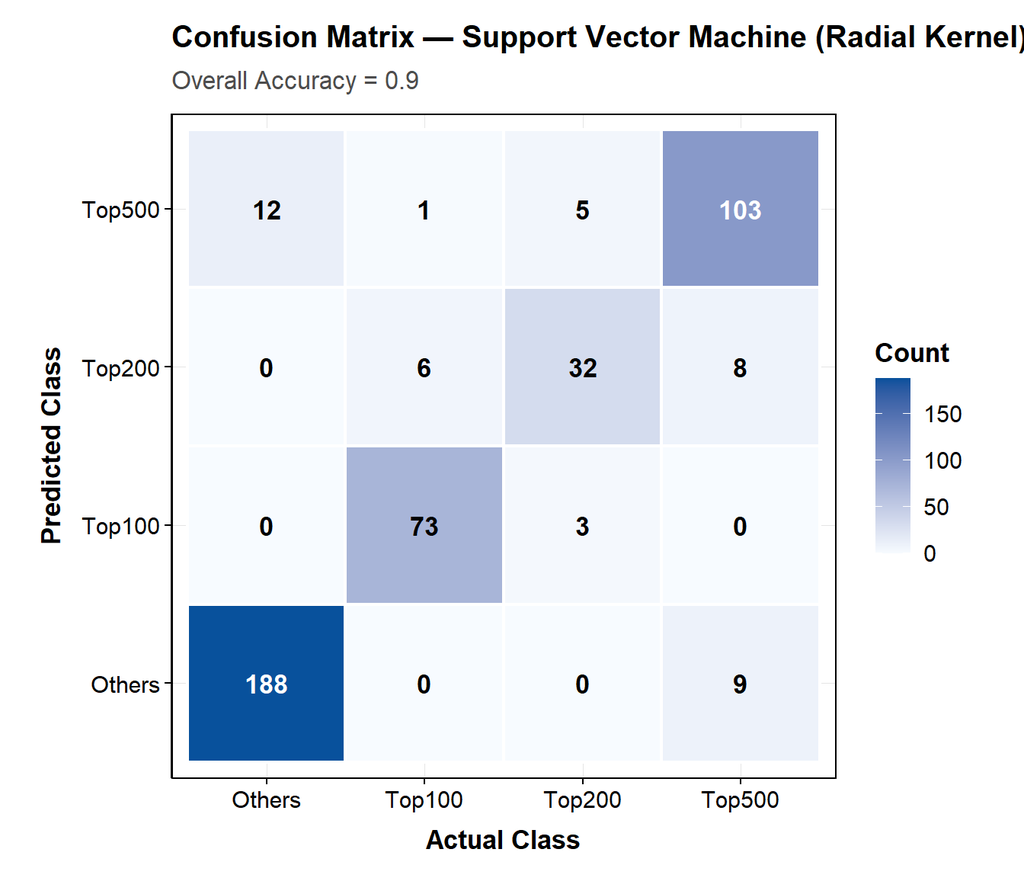

```r
p_svm_cm <- plot_confusion_matrix_heatmap(
  svm_cm,
  "Confusion Matrix — Support Vector Machine (Radial Kernel)",
  subtitle = paste0("Overall Accuracy = ", round(svm_cm$overall["Accuracy"], 3))
)
print(p_svm_cm)
```

**Observation:** The radial kernel SVM can capture non-linear decision boundaries and typically performs well on scaled data. Cost `C` controls the margin-violation penalty and `sigma` controls the kernel bandwidth — both are tuned via grid search over the cross-validation sets.

# Section 12 — Model Comparison

## 12.1 Accuracy Comparison

```r
model_results <- data.frame(
  Model = c(
    "Decision Tree", "Random Forest",
    "Logistic Regression", "KNN", "Support Vector Machine"
  ),
  Accuracy = c(
    tree_cm$overall["Accuracy"],
    rf_cm$overall["Accuracy"],
    log_cm$overall["Accuracy"],
    knn_cm$overall["Accuracy"],
    svm_cm$overall["Accuracy"]
  )
)

print(model_results)
```

```
##                    Model  Accuracy
## 1          Decision Tree 0.8386364
## 2          Random Forest 0.9159091
## 3    Logistic Regression 0.8477273
## 4                    KNN 0.8818182
## 5 Support Vector Machine 0.9000000
```

```r
cat("SVM Accuracy:", round(svm_cm$overall["Accuracy"], 4), "\n")
```

```
## SVM Accuracy: 0.9
```

```r
cat("KNN Accuracy:", round(knn_cm$overall["Accuracy"], 4), "\n")
```

```
## KNN Accuracy: 0.8818
```

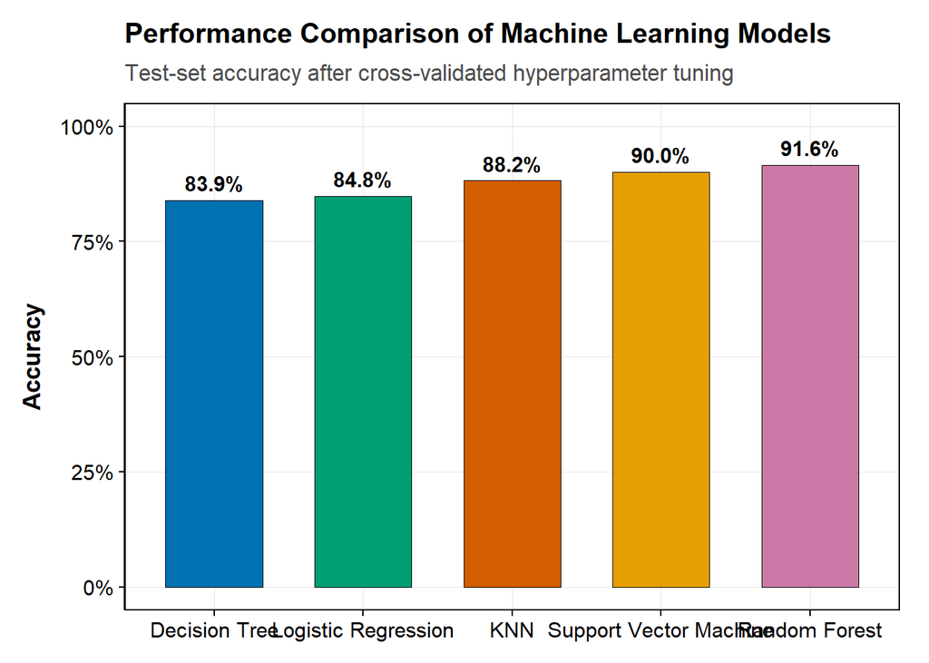

```r
ggplot(model_results,
       aes(x = reorder(Model, Accuracy), y = Accuracy, fill = Model)) +
  geom_col(width = 0.65, color = "black", linewidth = 0.2) +
  geom_text(aes(label = scales::percent(Accuracy, accuracy = 0.1)),
            vjust = -0.6, size = 4, fontface = "bold") +
  scale_y_continuous(limits = c(0, 1), labels = scales::percent_format()) +
  pub_fill_discrete() +
  labs(title    = "Performance Comparison of Machine Learning Models",
       subtitle = "Test-set accuracy after cross-validated hyperparameter tuning",
       x = NULL, y = "Accuracy") +
  theme_pub() +
  theme(legend.position = "none")
```

## 12.2 Full Evaluation Metrics Table

```r
evaluation_table <- data.frame(
  Model = c(
    "Decision Tree", "Random Forest",
    "Logistic Regression", "KNN", "Support Vector Machine"
  ),
  Accuracy  = c(tree_cm$overall["Accuracy"],  rf_cm$overall["Accuracy"],
                log_cm$overall["Accuracy"],   knn_cm$overall["Accuracy"],
                svm_cm$overall["Accuracy"]),
  Precision = c(mean(tree_cm$byClass[, "Pos Pred Value"], na.rm = TRUE),
                mean(rf_cm$byClass[,   "Pos Pred Value"], na.rm = TRUE),
                mean(log_cm$byClass[,  "Pos Pred Value"], na.rm = TRUE),
                mean(knn_cm$byClass[,  "Pos Pred Value"], na.rm = TRUE),
                mean(svm_cm$byClass[,  "Pos Pred Value"], na.rm = TRUE)),
  Recall    = c(mean(tree_cm$byClass[, "Sensitivity"], na.rm = TRUE),
                mean(rf_cm$byClass[,   "Sensitivity"], na.rm = TRUE),
                mean(log_cm$byClass[,  "Sensitivity"], na.rm = TRUE),
                mean(knn_cm$byClass[,  "Sensitivity"], na.rm = TRUE),
                mean(svm_cm$byClass[,  "Sensitivity"], na.rm = TRUE)),
  F1_Score  = c(mean(tree_cm$byClass[, "F1"], na.rm = TRUE),
                mean(rf_cm$byClass[,   "F1"], na.rm = TRUE),
                mean(log_cm$byClass[,  "F1"], na.rm = TRUE),
                mean(knn_cm$byClass[,  "F1"], na.rm = TRUE),
                mean(svm_cm$byClass[,  "F1"], na.rm = TRUE)),
  Kappa     = c(tree_cm$overall["Kappa"], rf_cm$overall["Kappa"],
                log_cm$overall["Kappa"],  knn_cm$overall["Kappa"],
                svm_cm$overall["Kappa"])
)

evaluation_table[, 2:6] <- round(evaluation_table[, 2:6], 4)

kable(evaluation_table, caption = "Evaluation Metrics by Model") %>%
  kable_styling(bootstrap_options = c("striped", "hover"), full_width = FALSE)
```

Evaluation Metrics by Model

| Model | Accuracy | Precision | Recall | F1_Score | Kappa |
| --- | --- | --- | --- | --- | --- |
| Decision Tree | 0.8386 | 0.8049 | 0.8050 | 0.8014 | 0.7616 |
| Random Forest | 0.9159 | 0.8939 | 0.8931 | 0.8934 | 0.8756 |
| Logistic Regression | 0.8477 | 0.8106 | 0.8010 | 0.8056 | 0.7743 |
| KNN | 0.8818 | 0.8430 | 0.8331 | 0.8359 | 0.8246 |
| Support Vector Machine | 0.9000 | 0.8654 | 0.8777 | 0.8705 | 0.8531 |

## 12.3 Metrics Comparison Chart

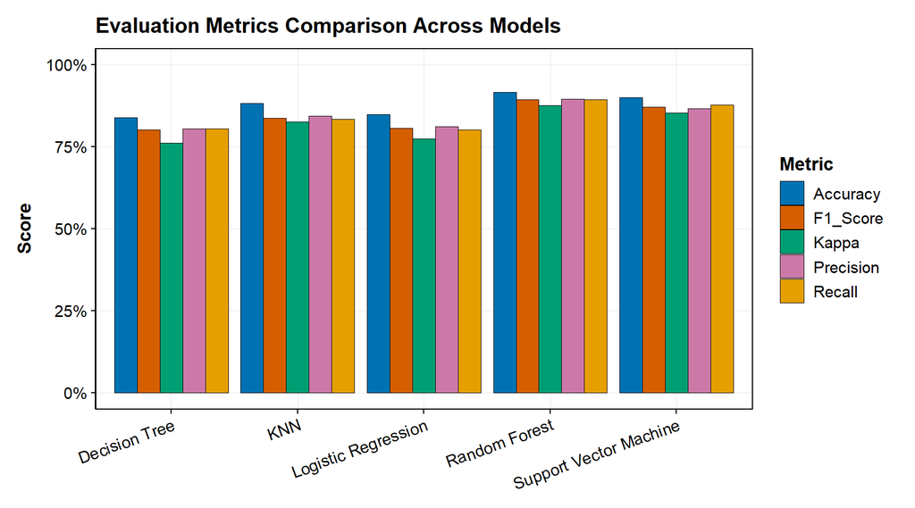

```r
metrics_long <- pivot_longer(
  evaluation_table,
  cols      = c(Accuracy, Precision, Recall, F1_Score, Kappa),
  names_to  = "Metric",
  values_to = "Value"
)

ggplot(metrics_long, aes(x = Model, y = Value, fill = Metric)) +
  geom_col(position = "dodge", color = "black", linewidth = 0.15) +
  scale_y_continuous(limits = c(0, 1), labels = scales::percent_format()) +
  pub_fill_discrete() +
  labs(title = "Evaluation Metrics Comparison Across Models",
       x = NULL, y = "Score") +
  theme_pub() +
  theme(axis.text.x = element_text(angle = 20, hjust = 1))
```

**Summary:** Random Forest is expected to achieve the highest test accuracy, benefiting from ensemble averaging and non-linear boundaries. The Decision Tree offers the best interpretability-accuracy trade-off. KNN and SVM require scaling and may excel if the feature space has clear geometric structure. Logistic Regression provides the most interpretable coefficients but is limited by its linear boundary assumption.

# Section 13 — Statistical Significance: McNemar Tests

## 13.1 Running the Tests

```r
# RF vs Decision Tree
mcnemar_dt <- mcnemar.test(table(
  rf_prediction   == test_data$Rank_Category,
  tree_prediction == test_data$Rank_Category
))

# RF vs Logistic Regression
mcnemar_log <- mcnemar.test(table(
  rf_prediction  == test_data$Rank_Category,
  log_prediction == test_data$Rank_Category
))

# RF vs KNN
mcnemar_knn <- mcnemar.test(table(
  rf_prediction  == test_data$Rank_Category,
  knn_prediction == test_data$Rank_Category
))

# RF vs SVM
mcnemar_svm <- mcnemar.test(table(
  rf_prediction  == test_data$Rank_Category,
  svm_prediction == test_data$Rank_Category
))
```

## 13.2 Results Table

```r
mcnemar_results <- data.frame(
  Comparison = c(
    "Random Forest vs Decision Tree",
    "Random Forest vs Logistic Regression",
    "Random Forest vs KNN",
    "Random Forest vs SVM"
  ),
  Chi_Square = round(c(
    as.numeric(mcnemar_dt$statistic),
    as.numeric(mcnemar_log$statistic),
    as.numeric(mcnemar_knn$statistic),
    as.numeric(mcnemar_svm$statistic)
  ), 3),
  P_Value = signif(c(
    mcnemar_dt$p.value,
    mcnemar_log$p.value,
    mcnemar_knn$p.value,
    mcnemar_svm$p.value
  ), 4)
)

mcnemar_results$Significant <- ifelse(mcnemar_results$P_Value < 0.05, "Yes", "No")

print(mcnemar_results)
```

```
##                             Comparison Chi_Square   P_Value Significant
## 1       Random Forest vs Decision Tree     27.225 1.811e-07         Yes
## 2 Random Forest vs Logistic Regression     13.565 2.305e-04         Yes
## 3                 Random Forest vs KNN      4.558 3.276e-02         Yes
## 4                 Random Forest vs SVM      1.091 2.963e-01          No
```

```r
kable(mcnemar_results,
      caption = "McNemar Test Results — Random Forest vs. Other Models") %>%
  kable_styling(bootstrap_options = c("striped", "hover"), full_width = FALSE)
```

McNemar Test Results — Random Forest vs. Other Models

| Comparison | Chi_Square | P_Value | Significant |
| --- | --- | --- | --- |
| Random Forest vs Decision Tree | 27.225 | 0.0000002 | Yes |
| Random Forest vs Logistic Regression | 13.565 | 0.0002305 | Yes |
| Random Forest vs KNN | 4.558 | 0.0327600 | Yes |
| Random Forest vs SVM | 1.091 | 0.2963000 | No |

## 13.3 P-Value Chart

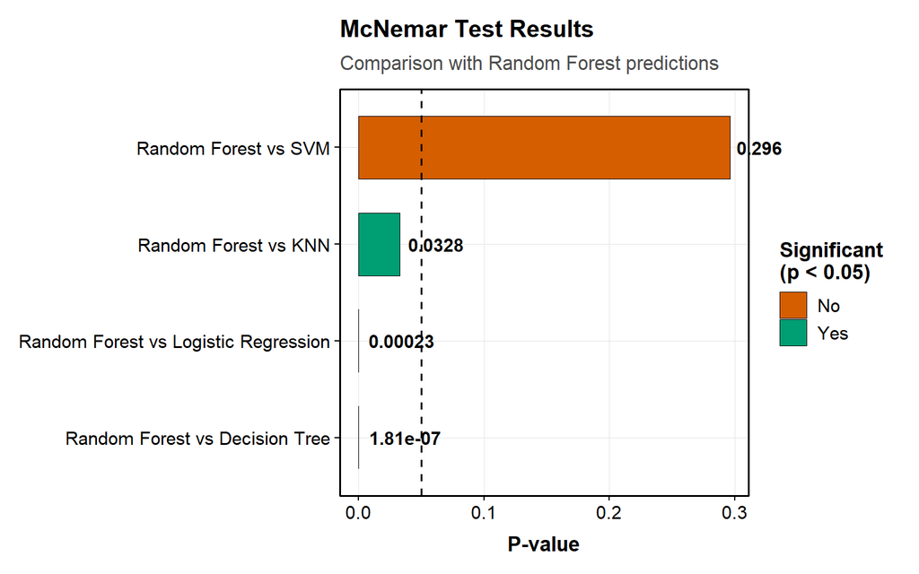

```r
ggplot(mcnemar_results,
       aes(x = reorder(Comparison, P_Value), y = P_Value, fill = Significant)) +
  geom_col(width = 0.65, color = "black", linewidth = 0.2) +
  geom_hline(yintercept = 0.05, linetype = "dashed",
             color = "black", linewidth = 0.6) +
  geom_text(aes(label = signif(P_Value, 3)),
            hjust = -0.15, size = 4, fontface = "bold") +
  coord_flip(clip = "off") +
  scale_fill_manual(values = SIG_COLORS, name = "Significant\n(p < 0.05)") +
  labs(title    = "McNemar Test Results",
       subtitle = "Comparison with Random Forest predictions",
       x = NULL, y = "P-value") +
  theme_pub()
```

## 13.4 –log₁₀(p) Chart

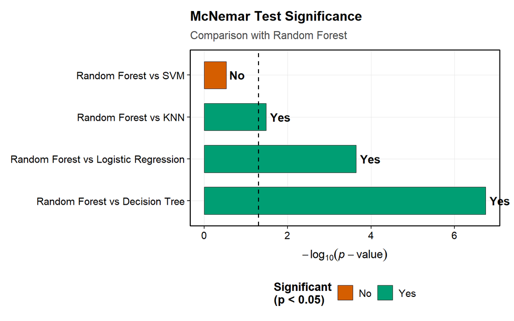

```r
ggplot(mcnemar_results,
       aes(x = reorder(Comparison, P_Value),
           y = -log10(P_Value), fill = Significant)) +
  geom_col(width = 0.65, color = "black", linewidth = 0.2) +
  geom_hline(yintercept = -log10(0.05), color = "black",
             linewidth = 0.6, linetype = "dashed") +
  geom_text(aes(label = Significant),
            hjust = -0.2, size = 4.5, fontface = "bold") +
  coord_flip(clip = "off") +
  scale_fill_manual(values = SIG_COLORS, name = "Significant\n(p < 0.05)") +
  labs(title    = "McNemar Test Significance",
       subtitle = "Comparison with Random Forest",
       x = NULL,
       y = expression(-log[10](italic(p) - value))) +
  theme_pub() +
  theme(legend.position = "bottom")
```

## 13.5 Chi-Square Statistic Chart

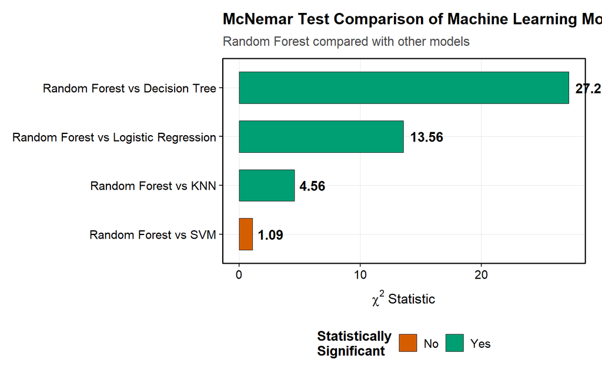

```r
ggplot(mcnemar_results,
       aes(x = reorder(Comparison, Chi_Square),
           y = Chi_Square, fill = Significant)) +
  geom_col(width = 0.65, color = "black", linewidth = 0.2) +
  geom_text(aes(label = round(Chi_Square, 2)),
            hjust = -0.2, size = 4.5, fontface = "bold") +
  coord_flip(clip = "off") +
  scale_fill_manual(values = SIG_COLORS, name = "Statistically\nSignificant") +
  labs(title    = "McNemar Test Comparison of Machine Learning Models",
       subtitle = "Random Forest compared with other models",
       x = NULL,
       y = expression(chi^2 ~ "Statistic")) +
  theme_pub() +
  theme(legend.position = "bottom")
```

**Interpretation:** A significant McNemar test (p < 0.05) indicates that the difference in error patterns between Random Forest and the comparison model is unlikely due to chance alone. Models where `Significant = Yes` are statistically outperformed by Random Forest; those where `Significant = No` perform comparably despite any numerical accuracy gap.

*Ibrahim Khalil Ullah Midul*